# Report on Qualitative Activity Recognition of Weight Lifting Exercises

### Following report predict the manner in which people exercise. Data used for this report can be downloaded from source http://groupware.les.inf.puc-rio.br/har

### Data have “classe”“ as the outcome variable which have 5 cateogrical values i.e.

- Class A -> exactly according to the specification.
- Class B -> throwing the elbows to the front.
- Class C -> lifting the dumbbell only halfway.
- Class D -> lowering the dumbbell only halfway.
- Class E -> and throwing the hips to the front.

### Weight Lifting Exercise data contain lot of predictor variables but our goal will be to use only the predictors whose data come from the accelerometers put on the belt, forearm, arm and dumbell i.e.

```
##  [1] "total_accel_belt"     "accel_belt_x"         "accel_belt_y"
##  [4] "accel_belt_z"         "total_accel_arm"      "accel_arm_x"
##  [7] "accel_arm_y"          "accel_arm_z"          "total_accel_dumbbell"
## [10] "accel_dumbbell_x"     "accel_dumbbell_y"     "accel_dumbbell_z"
## [13] "total_accel_forearm"  "accel_forearm_x"      "accel_forearm_y"
## [16] "accel_forearm_z"
```

## Overlay Density Plot

### As can be seen in the overlay plot, predictor variables are non-linear in nature so models like random forest or ada-boost can be useful.

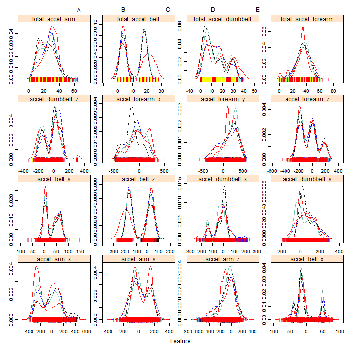

## 1. Random Forest model with only boosting as resampling method, name it "first”

```
##
## Call:
##  randomForest(x = x, y = y, mtry = param$mtry)
##                Type of random forest: classification
##                      Number of trees: 500
## No. of variables tried at each split: 2
##
##         OOB estimate of  error rate: 5.09%
## Confusion matrix:
##      A    B    C    D    E class.error
## A 4041   21   63   59    1     0.03441
## B  102 2626   82   16   22     0.07795
## C   38   51 2450   24    4     0.04558
## D   49   12  106 2231   14     0.07504
## E    5   38   22   20 2621     0.03141
```

### Plotting the “first” model

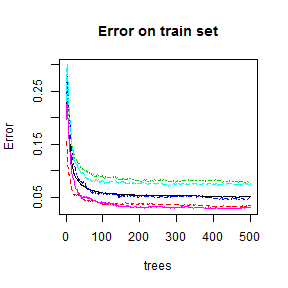

### Out of sample error on validation set for “first” model

```
## Confusion Matrix and Statistics
##
##           Reference
## Prediction    A    B    C    D    E
##          A 1040    0    0    0    0
##          B    0  726    0    0    0
##          C    0    0  621    0    0
##          D    0    0    0  603    0
##          E    0    0    0    0  688
##
## Overall Statistics
##
##                Accuracy : 1
##                  95% CI : (0.999, 1)
##     No Information Rate : 0.283
##     P-Value [Acc > NIR] : <2e-16
##
##                   Kappa : 1
##  Mcnemar's Test P-Value : NA
##
## Statistics by Class:
##
##                      Class: A Class: B Class: C Class: D Class: E
## Sensitivity             1.000    1.000    1.000    1.000    1.000
## Specificity             1.000    1.000    1.000    1.000    1.000
## Pos Pred Value          1.000    1.000    1.000    1.000    1.000
## Neg Pred Value          1.000    1.000    1.000    1.000    1.000
## Prevalence              0.283    0.197    0.169    0.164    0.187
## Detection Rate          0.283    0.197    0.169    0.164    0.187
## Detection Prevalence    0.283    0.197    0.169    0.164    0.187
## Balanced Accuracy       1.000    1.000    1.000    1.000    1.000
```

## We then tried k fold cross validation(k=10 and k=5) as resampling method with center and scale preprocessing

```r
library(caret)
trnControl<-trainControl(method="cv",preProcOptions=c("center","scale"),number=10)
trnControl1<-trainControl(method="cv",preProcOptions=c("center","scale"),number=5)
```

## 2. Random forest model with k fold cross validations (k=10 and 5) and preprocessing, name it “second” and “third”

```
##
## Call:
##  randomForest(x = x, y = y, mtry = param$mtry)
##                Type of random forest: classification
##                      Number of trees: 500
## No. of variables tried at each split: 2
##
##         OOB estimate of  error rate: 5.21%
## Confusion matrix:
##      A    B    C    D    E class.error
## A 4034   32   61   57    1     0.03608
## B   99 2625   88   14   22     0.07830
## C   37   63 2440   22    5     0.04947
## D   46   13  110 2229   14     0.07587
## E    6   33   23   21 2623     0.03067
```

```
##
## Call:
##  randomForest(x = x, y = y, mtry = param$mtry)
##                Type of random forest: classification
##                      Number of trees: 500
## No. of variables tried at each split: 2
##
##         OOB estimate of  error rate: 5.2%
## Confusion matrix:
##      A    B    C    D    E class.error
## A 4045   21   63   55    1     0.03345
## B  104 2611   93   20   20     0.08322
## C   38   63 2443   20    3     0.04831
## D   46   12  111 2229   14     0.07587
## E    7   28   26   21 2624     0.03030
```

### Plotting the “second” model

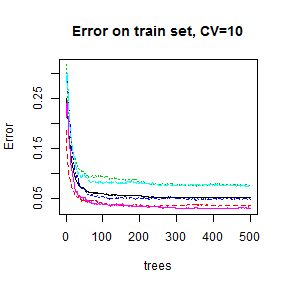

### Out of sample error on validation set for “second” model

```
## Confusion Matrix and Statistics
##
##           Reference
## Prediction    A    B    C    D    E
##          A 1040    0    0    0    0
##          B    0  726    0    0    0
##          C    0    0  621    0    0
##          D    0    0    0  603    0
##          E    0    0    0    0  688
##
## Overall Statistics
##
##                Accuracy : 1
##                  95% CI : (0.999, 1)
##     No Information Rate : 0.283
##     P-Value [Acc > NIR] : <2e-16
##
##                   Kappa : 1
##  Mcnemar's Test P-Value : NA
##
## Statistics by Class:
##
##                      Class: A Class: B Class: C Class: D Class: E
## Sensitivity             1.000    1.000    1.000    1.000    1.000
## Specificity             1.000    1.000    1.000    1.000    1.000
## Pos Pred Value          1.000    1.000    1.000    1.000    1.000
## Neg Pred Value          1.000    1.000    1.000    1.000    1.000
## Prevalence              0.283    0.197    0.169    0.164    0.187
## Detection Rate          0.283    0.197    0.169    0.164    0.187
## Detection Prevalence    0.283    0.197    0.169    0.164    0.187
## Balanced Accuracy       1.000    1.000    1.000    1.000    1.000
```

### Plotting the “third” model

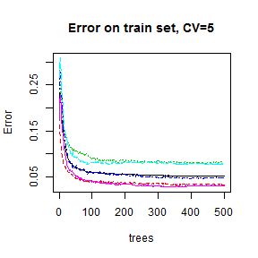

### Out of sample error on validation set “third” model

```
## Confusion Matrix and Statistics
##
##           Reference
## Prediction    A    B    C    D    E
##          A 1040    0    0    0    0
##          B    0  726    0    0    0
##          C    0    0  621    0    0
##          D    0    0    0  603    0
##          E    0    0    0    0  688
##
## Overall Statistics
##
##                Accuracy : 1
##                  95% CI : (0.999, 1)
##     No Information Rate : 0.283
##     P-Value [Acc > NIR] : <2e-16
##
##                   Kappa : 1
##  Mcnemar's Test P-Value : NA
##
## Statistics by Class:
##
##                      Class: A Class: B Class: C Class: D Class: E
## Sensitivity             1.000    1.000    1.000    1.000    1.000
## Specificity             1.000    1.000    1.000    1.000    1.000
## Pos Pred Value          1.000    1.000    1.000    1.000    1.000
## Neg Pred Value          1.000    1.000    1.000    1.000    1.000
## Prevalence              0.283    0.197    0.169    0.164    0.187
## Detection Rate          0.283    0.197    0.169    0.164    0.187
## Detection Prevalence    0.283    0.197    0.169    0.164    0.187
## Balanced Accuracy       1.000    1.000    1.000    1.000    1.000
```

## 3. Prediction of all models

### Prediction of testing set with “first” model

```
##  1  2  3  4  5  6  7  8  9 10 11 12 13 14 15 16 17 18 19 20
##  B  A  C  A  A  E  D  B  A  A  B  C  B  A  E  E  A  B  B  B
## Levels: A B C D E
```

### Prediction of testing set with “second” model

```
##  1  2  3  4  5  6  7  8  9 10 11 12 13 14 15 16 17 18 19 20
##  B  A  C  A  A  E  D  B  A  A  B  C  B  A  E  E  A  B  B  B
## Levels: A B C D E
```

### Prediction of testing set with “third” model

```
##  1  2  3  4  5  6  7  8  9 10 11 12 13 14 15 16 17 18 19 20
##  B  A  C  A  A  E  D  B  A  A  B  C  B  A  E  E  A  B  B  B
## Levels: A B C D E
```